# 手間の少ない副業 — チームで比べた結論 (2026-10-13)

回したチーム: 顧客理解とマーケ / 届け方とメディアミックス / 収益と検証 の3役を別々のAIで並行し、企画・制作とまとめはクロード。45案から10案に絞って、案ごとに「誰に・需要の根拠・違い・導線・稼ぎ方・2週間の指標」で比べた。

## 結論

1. **一番は「職業の乗り換え路線図」**。3役とも上位。AIで仕事が不安な人 (調査で65.8%) に「次に行ける先」を見せる形は、調べた範囲で見当たらない。図鑑の405職種がそのまま使え、資格・転職の紹介料 (A8、1件約2,000〜27,000円、9件申請中) に直結する
2. **二番は「資格の取る順番路線図」**。同じ部品で作れ、宅建アプリ・宅建の読者の受け皿になる。紹介料が直接取れる
3. **ただし、どの案より先に「動画→サイト」の導線を直す**。図鑑はIGで約70万再生でもサイト訪問がほぼ0。動画で全部見せず「自分の職種・資格を調べる入口」で終わらせる。直さずに案を足すと同じ失敗をくり返す (3役の共通の指摘)

## 比較 (10案)

| 案 | 見て嬉しい人 | 稼ぎ方 | 判定 |
| --- | --- | --- | --- |
| 職業の乗り換え路線図 | 仕事が不安な20〜40代 | 図鑑→資格・転職の紹介料 | ◎ 本命 |
| 資格の取る順番路線図 | これから資格を取る人 | 資格講座の紹介料 | ◎ 二番 |
| 職業1分解説ショート | 自分の仕事が気になる人 | 路線図への入口 (単体では回さない) | ○ 補助 |
| 都道府県タイル地図 | 「うちの県は何位?」の人 | 広告のみ (収益化まで遠い) | △ 自動化は最も楽、お金が遠い |
| AIと口論して覚える宅建 | 独学の宅建受験生 | 講座の紹介料 | △ 大手が強い。次の山は来春 |
| 恋愛・結婚の統計図解 | 結婚を考える20〜30代 | 広告のみ | △ 旬 (9月公表) はあるが別の読者 |
| AI秘書と働く日記 | AIを使い始めた会社員 | 有料note | △ 根拠弱い |
| 地価ランキング | 持ち家・投資家 | 広告 | × 旬が3月で単発 |
| 公的図版のストック販売 | 資料を作る人 | 1点売り | × 無料の公的ツールと競合 |
| 動物が働くAI動画 | 軽く笑いたい人 | 広告 | × 再生は取れても来ない |

YouTube の広告は、登録1,000人 + 90日でショート1,000万回 (または長尺4,000時間) が条件 (公式ヘルプ)。広告だけの案は年内ほぼ0円と見る。

## 二番カード: 資格の取る順番路線図

- 誰に: これから資格を取る社会人・学生 (宅建 → 行政書士 → FP などの「順番」記事は予備校各社が書いている = 需要の裏づけ)
- 違い: 勉強時間の目安を線の長さで見せる。宅建アプリの読者を受ける
- 稼ぎ方: 資格講座の紹介料。訪問1万で月12,000〜50,000円 (推測)
- 2週間: 訪問300以上・クリック20以上。やめる: 6週でクリック率1%未満

## メディアミックス (届け方の形)

- SNSのアカウントは2本だけ: ①図鑑・進路 (乗り換え路線図・職業1分) ②資格 (取る順番路線図・宅建)。路線図が2本をつなぐ
- 地図・統計の物はSNSに出さず、検索で来る「自分の県・町を引くページ」に回す
- 本人の週15分は、予約投稿の確認と数字を見るだけ

## 試作

- 職業の乗り換え路線図・都道府県タイル地図: 静止画 (下に)。作ったのは別のAI。欠点: 路線図の矢印の一部が危険度の高い駅に向いていて、見出し「矢印の先は危険度の低い職種」と合わない (本番前に直す)

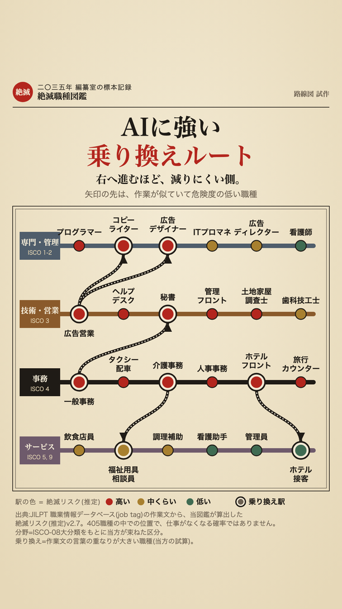

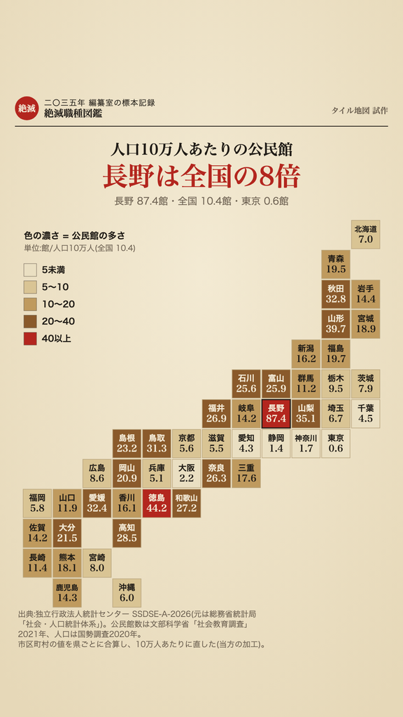

- AIと口論して覚える宅建: 生活ログ1日分から匿名の台本・投稿を作った (非公開。本人の会話は外に出さない)

## 決めてほしいこと (1問)

どれから試す？

1. 導線を直してから、職業の乗り換え路線図 (おすすめ)
2. 職業と資格の路線図を両方
3. まず導線を直すだけ (新しい案は足さない)
4. 別の案 (一覧から)

## 守ったこと

- 成人向けは市場と規約の分析だけ (作っていない)。子ども・赤ちゃんは実在の子を使わない案だけ
- 生活ログ・写真・位置はこのページに入れていない
- 数字のうち、確かめられなかった物は「推測」「調べた範囲」と書いた